# Toto

Andrea Low

10/02/2022

The grand prize for Toto in Singapore this week (10 Feb 2022) is 16 million. What are the expected returns for placing a bet?

### The Set Up

A buyer picks at least six numbers, from 1 to 49.

At the draw, 6 winning numbers + 1 additional number is drawn

3 or more winning numbers on a ticket matching the 7 numbers drawn qualifies the buyer for a cash prize. The prize money escalates with the increase in numbers matched.

Upper bound: All 7 numbers drawn match with the buyer's numbers (with the winner winning both group 1 and group 2 of the draw.

If 6 numbers on the Toto ticket matches the 6 numbers drawn (apart from the additional number), the jackpot (Group 1) prize is won

### The odds

6 numbers are drawn from a list of 49 with no repeats

```r
total.possibilities = factorial(49)/(factorial(43)*factorial(6))
base.odds = 1/total.possibilities
```

### Expected values

Consider only Group 1 grand prize (guessing all 6 drawn numbers correctly) = 16 million

```r
# Change this variable here as the top prize adjusts
grandprize = 16000000
```

Expected earnings for a regular bet where you draw 6 numbers, paying $1

```r
totalcost.1 = 1
ev.1 = grandprize*base.odds - totalcost.1
ev.1
```

```
## [1] 0.1441798
```

What if you buy a System 7 ticket, drawing 7 numbers?

```r
totalcost.7 = 7
odds.7 = 7*base.odds
ev.7 = grandprize*odds.7 - totalcost.7
ev.7
```

```
## [1] 1.009259
```

Or the other end, System 12?

```r
totalcost.12 = 924
odds.12 = 924*base.odds
ev.12 = grandprize*odds.12 - totalcost.12
ev.12
```

```
## [1] 133.2221
```

Looks like if you're going to buy Toto, you should buy System 12 and split the cost or something

Let's take a look at how the expected payoff evolves with the ticket bought

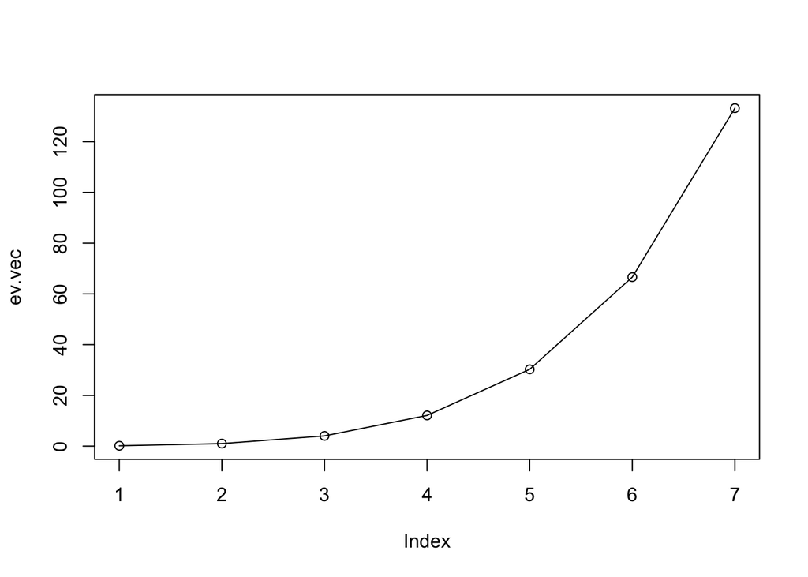

```r
# Odds for each system draw

odds.multiplier = c(1,7,28,84,210,462,924)
odds = base.odds*odds.multiplier

# Costs are priced according to odds
costs = odds.multiplier

# Expected values
ev.vec = grandprize*odds - costs
plot(ev.vec)
lines(ev.vec)
```

So. Fun stuff happens when probabilities are small but outcomes have large magnitudes.

Actually, lets consider all the group prizes now

We know the jackpot prize is 38% of the total pool

```r
# Prize money
group2 = 8*grandprize/38
group3 = 5.5*grandprize/38
group4 = 3*grandprize/38
group5 = 50
group6 = 25
group7 = 10

# Odds by group
group2.odds = 1/2330636
group3.odds = 1/55491
group4.odds = 1/22197
group5.odds = 1/1083
group6.odds = 1/812
group7.odds = 1/61
```

Now we figure out our expected earnings with a System 12 ticket

```r
# Expected payoffs

payoffs =  c(grandprize, group2, group3, group4, group5, group6, group7) * c(odds.12, group2.odds, group3.odds, group4.odds, group5.odds, group6.odds, group7.odds)

final = sum(payoffs) - 924
final
```

```
## [1] 233.5477
```

EV evolves linearly with the size of the pool

Considering only System 12 tickets for this and jackpot prizes from 1 - 16 million here:

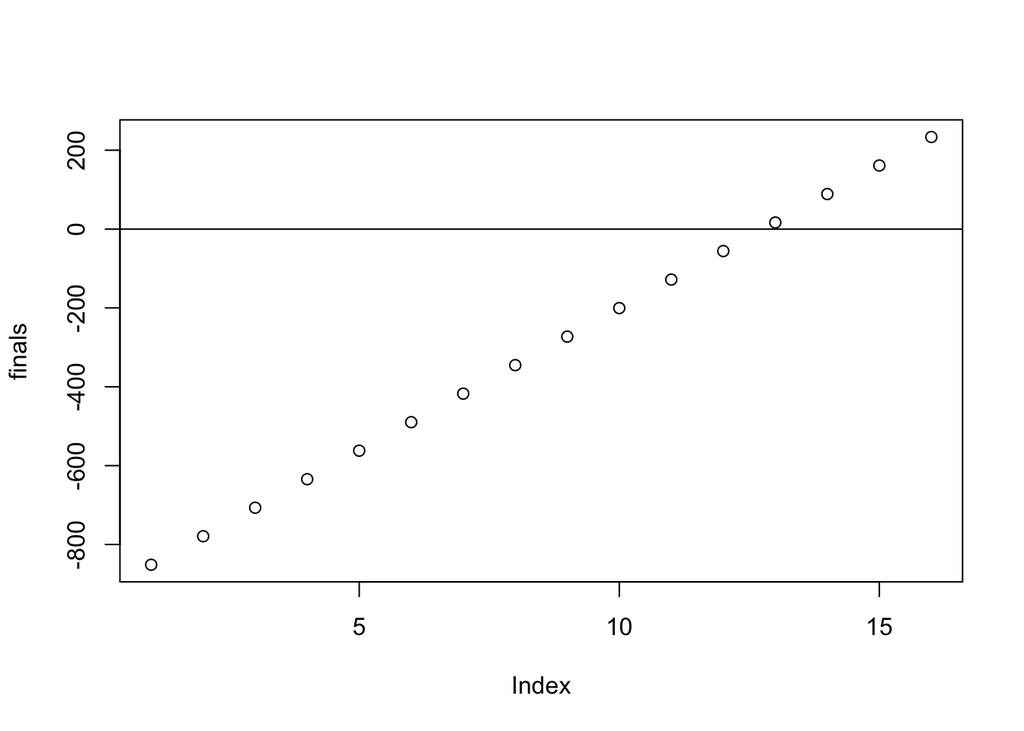

Don't buy a System 12 ticket unless the grand prize is at least 13million